# Exchange Argument

Miguel Miní

19/11/2020

El argumento de intercambio es un argumento greedy en el cual mejoramos de forma gradual la solución por medio de intercambiar desiciones.

### Asignación para Minimizar la Latencia

Consideremos otra vez una situación en la cual tenemos un único recurso y un conjunto de $n$ peticiones para usar el recurso por un invervalo de tiempo. Asumimos que el recurso es disponible iniciando en un tiempo s. En contraste a los problemas previos cada petición ahora es más flexible. En vez de iniciar y finalizar en un tiempo fijo, la petición $i$ tiene un deadline $d_i$, y usa un intervalo continuo de $t_i$ unidades del recurso, aunque puede iniciar en cualquier tiempo hasta el deadline y peticiones distintas deberian ser asignadas a intervalos no sobrelapados. Existen muchas funciones objetivas que podriamos usar para optimizar para encarar este problema, y algunas son computacional mas costosas que otras. Aquí consideramos un objetivo natural que puede optimizar por un algoritmo greedy. Supongamos que planeamos satisfaces cada petición, pero tenemos permitido dejar ciertas peticiones ser ejecutadas tarde. Nuestro objetivo será asignar un intervalo de tiempo de $t_i$ unidades de tiempo a cada intervalo. Nosotros diremos que una petición $i$ es tardada si esta falla el deadline, que es, si $f_i > d_i$. La tardanza de tal petición $i$ es definida como $l_i = f_i - d_i$. Decimos que $l_i = 0$ si la petición $i$ no es tardada. Nuestro objetivo en este nuevo problema de optimización debería ser asignar todas las peticiones, usando intervalos no sobrelapados, tal que minimize la máxima tardanza, $L = \max\limits_i l_i$.

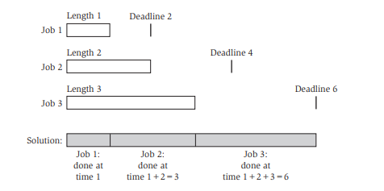

## Diseñando el Algoritmo

¿Cómo luce un algoritmo greedy para este problema? Hay muchos enfoques greedies naturales en el cual consideramos la data $(t_i, ~d_i)$ acerca de los trabajos y usa un orden acordando a alguna regla.

- Un enfoque greedy puede ser ordenar los trabajos en orden creciente a la longitud $t_i$ tal que nosotros resolvemos el trabajo más corto más rápido. Esto inmediatamente suena muy simplista, como este ignora completamente los deadlines de los trabajos. Y en ese sentido, consideremos una instancia con dos trabajos donde el primer trabajo tiene $t_1 = 1$ y $d_1 = 100$, mientras que el segundo trabajo tiene $t_2 = 10$ y $d_2 = 10$. Entonces el el segundo trabajo debe ser iniciado antes si queremos conseguir una tardanza $L = 0$.
- El ejemplo previo sugiere que nosotros debemos colocar los trabajos con el tiempo disponible $d_i - t_i$ menor posible primero, tal que un algoritmo más natural podría ser ordenar en orden incremental $d_i - t_i$.

Desafortunadamente, esta regla greedy falla igualmente. Considera una instancia con dos trabajos donde el primer trabajo tiene $t_1 = 1$ y $d_1 = 2$, mientras el segundo trabajo tiene $t_2 = 10$ y $d_2 = 10$. Ordenando por la regla deberia colocar el segundo trabajo primero y el primer trabajo debería incurrir una tardanza de $9$. Por otro lado, si nosotros realizamos el primer trabajo, y luego el segundo, esto debería incurrir en una tardanza de solo 1.

Este es, sin embargo, un igualmente básico algoritmo gredy que siempre produce una solución óptima. simplemente ordenamos los trabajos en orden creciente de sus deadlines $d_i$, y asignar estos en ese orden. Esta es una base intuitiva para esta regla: deberiamos asegurarno que los trabajo con menor deadline son completador primero. Así mismo, es un poco difícil para creer por que este algoritmo siempre produce una solución óptima, sobretodo porque no se fija en la longitud de los trabajos.

Anteriormente, éramos escépticos sobre el enfoque que clasificaba por longitud, por motivos que no usaban los deadlines; pero ahora estamos considerando una solución que desecha los tiempos. Sin embargo, este enfoque produce soluciones óptimas, y ahora lo demostraremos. Primero especificamos alguna notación que será útil al hablar sobre el algoritmo. Al cambiar el nombre de los trabajos si es necesario, podemos asumir que los trabajos son etiquetados en el orden de sus fechas límite, es decir, tenemos $d_1 \le \dots \le d_n$.

Nosotros deberiamos simplemente asignar todos los trabajos en este orden. De nuevo, sea $s$ el tiempo inicial para todos los trabajos. El trabajo 1 inicia en el tiempo $s = s_1$ y finaliza en $f_1 = s_1 + t_1$; trabajo 2 debería inicial en $s_2 = f_1$ y finalizar en $f_2 = s_2 + t_2$; y así sucedivamente. Nosotros deberiamos designar por $f$ al tiempo final del último intervalo asignado.

## Algoritmo

```cpp
Ordenar los trabajos en orden de sus deadlines
asumimos por simplicidad de notación d_1 <= ... <= d_n
Inicialmente, f = s
Considera los trabajos i = 1, ..., n en este orden
Asignar trabajo i para el intervalo de tiempo [s_i = f, f_i = f + t_i]
Sea f = f + t_i
Retornar el conjunto de intervalos [s_i, f_i] para i = 1, ..., n.
```

```cpp
struct Job {
  int t, d;
};

struct Interval {
  int l, r;
};

vector<Interval> solve(vector<Job> p, int s) {
  int n = p.size();
  vector<int> ind(n);
  atoi(ind.begin(), ind.end(), 0);
  sort(ind.begin(), ind.end(), [&](int i, int j) {
    return p[i].d < p[j].d;
  });
  vector<Interval> res(n);
  for (int i = 0; i < n; ++i) {
    res[ind[i]] = {s, s + p[ind[i]].t};
    s += p[ind[i]].t;
  }
  return res;
}
```

## Analizando el Algoritmo

Para razonar sobre la optimalidad del algoritmo, primero observamos que el horario que produce no tiene “huecos”, momentos en los que la máquina no está funcionando, podemos razonar y no es muy diffícil de probar que siempre existe una asignación óptima que no tiene huecos.

#### Afirmación:

**Existe un horario óptimo sin tiempo de inactividad.**

Ahora bien, ¿cómo podemos probar que nuestro algoritmo es óptimo, es decir, el retraso máximo $L$ es lo más pequeño posible? Como en análisis anteriores, Empiece por considerar un horario óptimo $O$. Nuestro plan aquí es gradualmente modificar $O$, conservando su optimalidad en cada paso, pero eventualmente transformando en un horario que es idéntico al horario $A$ encontrado por el algoritmo greedy. Nos referimos a este tipo de análisis como un argumento de intercambio. Primero intentamos caracterizar los horarios de la siguiente manera. Decimos que un el horario en $A$ tiene una inversión si un trabajo $i$ con fecha límite $d_i$ está programado antes otro trabajo $j$ con fecha límite anterior $d_j < d_i$. Nótese que, por definición, El programa $A$ producido por nuestro algoritmo no tiene inversiones. Si hay trabajos con plazos idénticos, puede haber muchos horarios diferentes sin inversiones. Sin embargo, podemos demostrar que todos estos horarios tienen el mismo tardanza máxima L.

#### Afirmación:

**Todos los horarios sin inversiones y sin tiempo de inactividad tienen la mismo tardanza máxima.**

#### Prueba.

Si dos programas diferentes no tienen inversiones ni tiempo de inactividad, entonces Puede que no produzcan exactamente el mismo orden de trabajos, pero solo pueden diferir en el orden en que se programan los trabajos con plazos idénticos. Considerar tal fecha límite $d$. En ambos horarios, los trabajos con fecha límite $d$ están todos programados consecutivamente (después de todos los trabajos con fechas límite anteriores y antes de todos los trabajos con plazos posteriores). Entre los trabajos con fecha límite $d$, el último tiene el mayor tardanza, y esta tardanza no depende del orden de los trabajos.

#### Programación para minimizar los retrasos: un argumento de intercambio.

El paso principal para mostrar la optimización de nuestro algoritmo es establecer que hay un horario óptimo que no tiene inversiones ni tiempo de inactividad. Para hacer esto, comenzaremos con cualquier horario óptimo sin tiempo de inactividad; entonces lo haremos convertirlo en un horario sin inversiones sin aumentar su máximo retraso. Por lo tanto, la programación resultante después de esta conversión será óptima también.

#### Afirmación:

**Existe un horario óptimo que no tiene inversiones ni tiempo de inactividad.**

#### Prueba.

Hemos probado que hay un horario óptimo sin tiempo de inactividad. La prueba consistirá en una secuencia de declaraciones. El primero de ellos es sencillo de establecer:

1. Si $O$ tiene una inversión, entonces hay un par de trabajos $i$ y $j$ tales que $j$ es programado inmediatamente después de $i$ y tiene $d_j$ < $d_i$.

De hecho, considere una inversión en la que se programa un trabajo en algún momento antes un trabajo por $d_a > d_b$. Si avanzamos en el orden programado de trabajos de $a$ a $b$ uno a la vez, tiene que llegar un punto en el que la fecha límite que vemos disminuye por primera vez. Esto corresponde a un par de trabajos consecutivos que forman una inversión.

Ahora suponga que $O$ tiene al menos una inversión, y por (a), sean $i$ y $j$ un par de solicitudes invertidas que son consecutivas en el orden programado. Nosotros disminuiremos el número de inversiones en $O$ al intercambiar las solicitudes $i$ y $j$ en el programa $O$. El par ($i$, $j$) formó una inversión en $O$, esta inversión es e liminada por la swap, y no se crean nuevas inversiones. Así tenemos

2. Despues de intercambiar $i$ y $j$ nosotros tenemos una asignación con una inversión menos.

La parte más difícil de esta prueba es argüir que la asignación invertida es además óptima.

3. La nueva asignación con el intercambio tiene una máxima tardanza no mayor que la de $O$.

Es claro que si nosotros probamos (c), entonces nosotros estamos listos, el inicial estado $O$ puede tener a lo más $\binom{n}{2}$ inversiones (si todos los pares son invertidos), y por tanto despues de a lo más $\binom{n}{2}$ inversiones nosotros obtendriamos una solución sin inversiones.

#### Prueba de (c).

Nosotros inventamos alguna notación para describir el orden $O$: asumir que cada petición $r$ is asignada el intervalo de tiempo $[s_r, ~f_r]$ y tiene tardanza $l^{'}_r$. Sea $L^{'} = \max\limits_r ~l^{'}_r$ la máxima latencia de este ordenamiento.

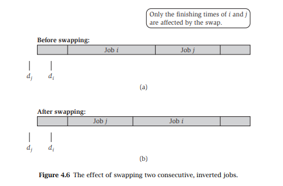

Sea $\bar{O}$ la asignación intercambiada; nosotros deberiamos usar $\bar{s_r}$, $\bar{f_r}$, $\bar{l_r}$, y $\bar{L_r}$ para denotar las cantidades correspondientes en el ordenamieno intercambiado.

Ahora recapitulando nuestros dos adjacentes, trabajos invertidos $i$ y $j$. La situación es señalada en la imagen anterior. El tiempo de finalización de $j$ antes del swap es exactamente igual al tiempo de finalización de $i$ después del swap. Así todos los otros trabajos a parte de $i$ y $j$ finalizan en el mismo tiempo en las dos asignaciones. Más aún, trabajo j debería finalizar antes en el nuevo ordenamiento, y por tanto los intercambios no incrementan la tardanza del trabajo $j$.

$\bar{l_i} = f_j - d_i < f_j - d_j = l^{'}_j$

Por tanto la tardanza de la signación $O$ fue $L^{'} \ge l^{'}_j > \bar{l_i}$, esto muestra que los intercambios no incrementan la máxima latencia de la asignación.

#### Teorema:

**La asignación $A$ producida por el algoritmo greedy tiene una tardanza óptima L.**

#### Prueba:

Hemos probado que existe una asignación óptima sin inversiones. También que todas las asignaciones sin inversiones tienen la misma tardanza máxima, y así la asignación obtenida por el algoritmo greedy es óptima.